# Bicycle Rentals exploration by Sreejith Gopinath

# Bivariate analysis

*Talk about some of the relationships you observed in this part of the investigation. How did the feature(s) of interest vary with other features in the dataset?*  
The number of bicycle rentals correlate strongly with the year and hour of the day. The former can be attributed to the assumption that the popularity of the rental service increased in the second year. This assumption is inconclusive because we only have data from two years. I do not see any particularly strong relationships between the number of bicycle rentals and other features in the dataset like humidity, weather temperature, feeling temperature, etc., (I consider those relationships that have an R^2 value > 0.50 to be a strong relationship).  
From the exploration that I conducted into the data, I see that about 16% of total bicycle rentals on a given day can be predicted by the prevailing temperature on that day.  
I also see that a whopping 94% of total bicycle rentals on a given day can be predicted by the number of users that are registered with the service as on that day.  
Given the preceding findings, I looked to see if there is a strong relationship between the number of casual bicycle renters and any other feature in the dataset. The strongest correlation I found was between casual ridership and normalized temperature - roughly 21% of casual bicycle rentals may be predicted by looking at the normalized prevailing temperatures for the day.

*Did you observe any interesting relationships between the other features (not the main feature(s) of interest)?*  
I looked at the relationships between some more features in the dataset. I see that there is a moderate relationship between humidity and the prevailing weather situation of the day. I see that there is a strong relationship between the normalized temperature on a given day and the corresponding season.

*What was the strongest relationship you found?*  
The strongest relationship I found was between the total bicycle rental numbers and number of registered renters. The other strong relationship I found was between the prevailing daily normalized temperatures and the season.

# Multivariate Plots Section

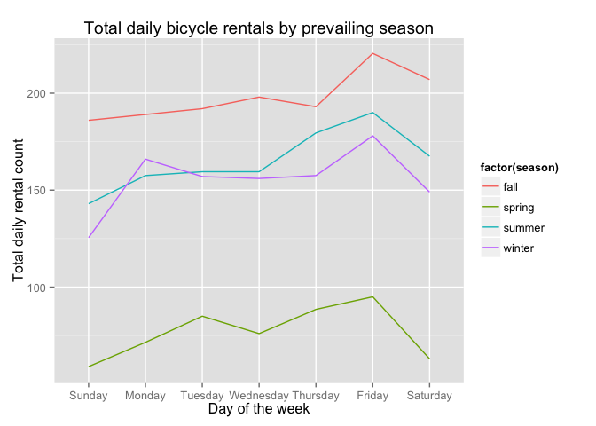

We see that daily median ridership for each day of the week is lowest in spring and highest in the fall seasons. The daily medians numbers follow a closer trend early in the week in summer and winter. I chose to include this plot because it shows very clearly the seasonal trends by day of the week. From this plot, we see why the prevailing season may be an acceptable indicator of bicycle rental numbers.

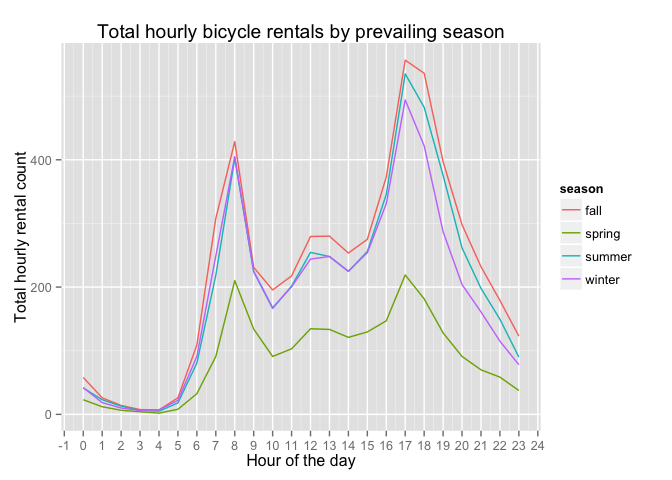

Looking at the median hourly ridership numbers, we see that the numbers are lowest in spring, while they follow a closer trend in the other seasons. The numbers are pretty much the same in the early hours of the day(owing to the extremely low rentals). For hourly numbers in summer, fall and winter, we see they closely converge at around 9:00am and between 4:00pm and 5:00pm - showing that these are primarily planned rentals. I chose to include this chart because it supplements the investigation we performed in the previous plot. When we look at the plot above, we see that the seasonal trends hold for pretty much the entire range of hours.

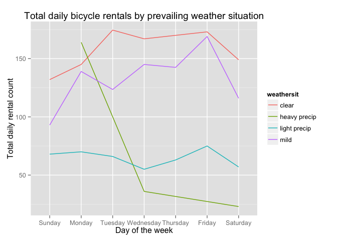

The preceding plot shows the median daily bicycle rentals depending on the prevailing weather situation of the day. Heavy precipitation seems to not deter bicycle renter on Mondays and Tuesdays, while on other days, heavy precipitation ensures low ridership. As predictable, highest bicyle ridership happens on clear days, followed by mild weather days and then on days that see light precipitation. I chose to include this plot because it reveals the daily bicycle rental trends by prevailing weather situation - and why there may not be a close correlation between the rental numbers and prevailing weahter.

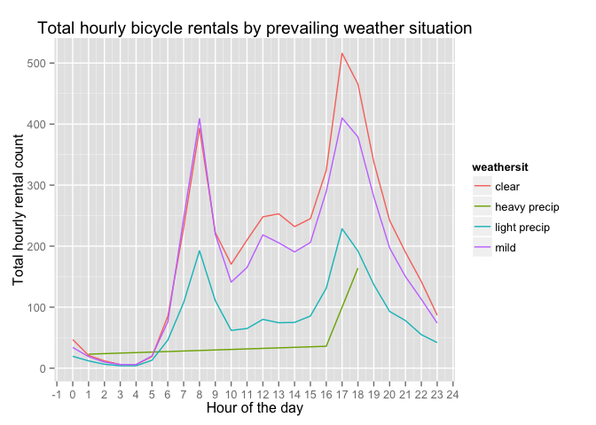

These plots above show how the hourly and daily bicycle rentals depending on the weather situation and the seasons. I wonder how these trends would vary with temperature, humidity and windspeed factors too.

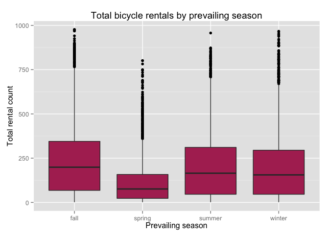

```
##        Min. 1st Qu. Median  Mean 3rd Qu. Max.
## fall      1      68  199.0 236.0     345  977
## spring    1      23   76.0 111.1     158  801
## summer    1      46  165.0 208.3     311  957
## winter    1      46  155.5 198.9     295  967
```

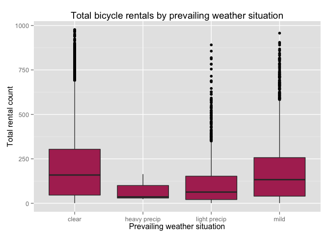

```
##              Min. 1st Qu. Median   Mean 3rd Qu. Max.
## clear           1    46.0    159 204.90   304.0  977
## heavy precip   23    29.5     36  74.33   100.0  164
## light precip    1    21.0     63 111.60   152.5  891
## mild            1    40.0    133 175.20   257.0  957
```

The preceding boxplots reinforce our findings that bicycle rentals are lowest in spring, followed by winter and summer and highest in the fall. Looking at the stats for each quartile, we see that the trends are close for the other three seasons except spring. We also see that periods of precipitation show lower bicycle rentals in the initial quartiles than for higher quartiles. *The main anomaly we see is that for the first quartile, bicycle rentals are higher in periods of heavy precipitation than in periods of light precipitation.*Towards the higher quartiles, though, we see that bicycle rentals in non-precipitative weather dominates.  
I chose to include these plots because in addition to seeing the median numbers, we also get a feel for whether the bicycle rental numbers varied in a wide range or not.

Since bicycle rentals are dominated by registered users, and because we saw from prior analysis that bicycle rental trends closely match office/school-going patters, I thought that it might be a good idea to explore the trends among casual users. I added a new column to the dataframe to represent the ratio of casual user rentals to the total renters.

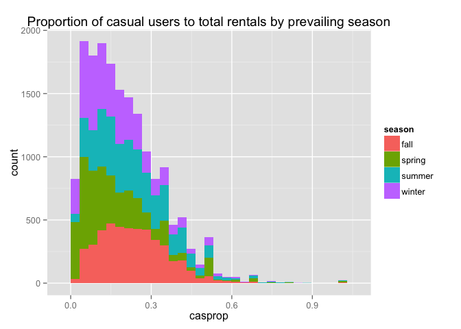

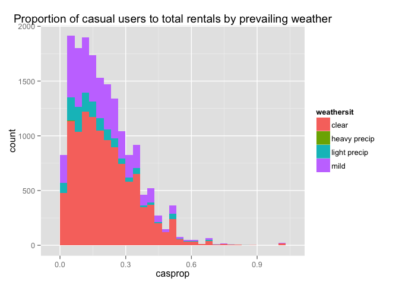

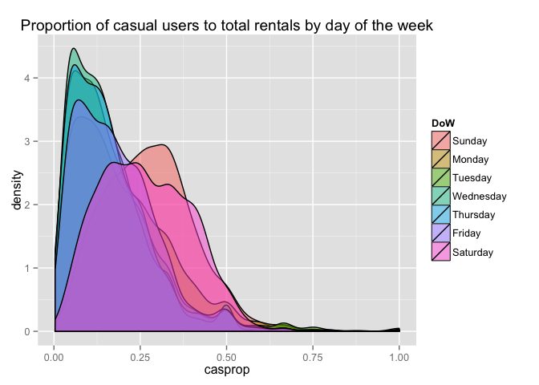

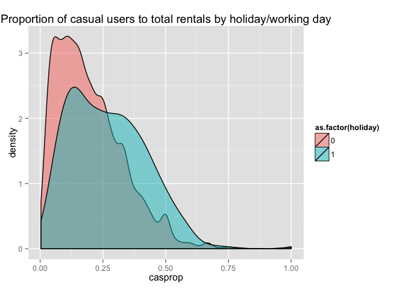

All of these plots reinforce the findings that we reached using earlier histograms and plots. Now, in order to build a linaear model to predict bicycle ridership, I’m going to decide on a set of variables that correlate with ridership.

[figure not shown]

I chose to include this plot because we already found out, from previous charts and analyses, how certain hours of the day are popular with bicycle renters. I wanted to see how the bicycle rental numbers varied by hour of the day and the prevailing seasons, and how the data points were distributed. We see that the trends in this chart follow the trends we saw earlier, that the middle portion of the day is a clear favorite among bicycle renters except in spring, where the trends are a little diluted.

[figure not shown]

From the plots above, we see how clear weather is a favorite among bicycle renters, with higher number of hourly rentals happening in this weather. The next favorite is mild weather. Periods of light precipitation see moderate rentals, while periods of heavy precipitation see almost no rentals. I chose to include this plot because we already found out, from previous charts and analyses, how certain hours of the day are popular with bicycle renters and wanted to see how the bicycle rental numbers varied by hour of the day and the prevailing seasons, and how the data points were distributed.  
From the plots above and the r^2 values of the linear models above, we can deduce that the features that may help us predict total bicycle rentals on any given day are “registered”, “temp”, “hr”, “season”, “weathersit”, in the order of confidence. Let’s try to build a linear prediction model using these features and see if we can predict bicycle rental numbers with a high level of confidence.

```
##
## Calls:
## m1: lm(formula = I(cnt) ~ I(registered), data = df_master)
## m2: lm(formula = I(cnt) ~ I(registered) + temp, data = df_master)
## m3: lm(formula = I(cnt) ~ I(registered) + temp + hr, data = df_master)
## m4: lm(formula = I(cnt) ~ I(registered) + temp + hr + season, data = df_master)
## m5: lm(formula = I(cnt) ~ I(registered) + temp + hr + season + weathersit,
##     data = df_master)
## m6: lm(formula = I(cnt) ~ I(registered) + temp + hr + season + weathersit +
##     windspeed, data = df_master)
##
## =============================================================================================================
##                                      m1           m2           m3           m4           m5           m6
## -------------------------------------------------------------------------------------------------------------
## (Intercept)                      10.296***    -25.759***   -33.535***   -56.904***   -53.708***   -55.745***
##                                  (0.460)       (0.835)      (0.920)      (1.857)      (1.866)      (1.884)
## I(registered)                     1.165***      1.129***     1.114***     1.112***     1.109***     1.108***
##                                  (0.002)       (0.002)      (0.002)      (0.002)      (0.002)      (0.002)
## temp                                           83.584***    83.145***   109.100***   107.789***   107.100***
##                                                (1.661)      (1.644)      (2.622)      (2.611)      (2.609)
## hr                                                           0.893***     0.805***     0.827***     0.796***
##                                                             (0.046)      (0.047)      (0.047)      (0.047)
## season: spring/fall                                                      18.307***    18.247***    17.099***
##                                                                          (1.332)      (1.326)      (1.333)
## season: summer/fall                                                      16.161***    16.560***    15.863***
##                                                                          (0.924)      (0.920)      (0.923)
## season: winter/fall                                                      13.241***    13.651***    13.454***
##                                                                          (1.111)      (1.107)      (1.105)
## weathersit: heavy precip/clear                                                         0.538        0.633
##                                                                                      (22.388)     (22.355)
## weathersit: light precip/clear                                                       -12.852***   -13.401***
##                                                                                       (1.103)      (1.104)
## weathersit: mild/clear                                                                -5.546***    -5.379***
##                                                                                       (0.683)      (0.683)
## windspeed                                                                                          17.916***
##                                                                                                    (2.470)
## -------------------------------------------------------------------------------------------------------------
## R-squared                              0.945        0.952        0.953        0.954        0.954        0.955
## adj. R-squared                         0.945        0.952        0.953        0.954        0.954        0.954
## sigma                                 42.511       39.716       39.302       38.948       38.759       38.701
## F                                 299011.649   172556.049   117596.137    59925.300    40359.602    36436.869
## p                                      0.000        0.000        0.000        0.000        0.000        0.000
## Log-likelihood                    -89825.690   -88643.242   -88460.671   -88301.904   -88215.940   -88189.651
## Deviance                        31402836.983 27407601.645 26837762.249 26351857.617 26092447.751 26013625.792
## AIC                               179657.381   177294.484   176931.343   176619.808   176453.880   176403.301
## BIC                               179680.670   177325.536   176970.158   176681.913   176539.274   176496.457
## N                                  17379        17379        17379        17379        17379        17379
## =============================================================================================================
```

To the variables I mention in the section above, I added the “windspeed” variable to see if factoring it in would give my prediction model some more accuracy. We see that the prediction model I just built can help predict bicycle rentals on a given day with about 95.5% confidence.

# Multivariate Analysis

*Talk about some of the relationships you observed in this part of the investigation. Were there features that strengthened each other in terms of looking at your feature(s) of interest?*  
Many of the variables interact and strengthen each others’ influence over bicycle rental numbers. For example, temperature, humidity and windspeed are tightly related to the weather situation. Each season has a weather situation that dominates a majority of the days in that season.

*Were there any interesting or surprising interactions between features?*  
I did not see any surprising relationships between features in the dataset.

*Did you create any models with your dataset? Discuss the strengths and limitations of your model.*  
Yes, I created a prediction model with the dataset. The main strength of my prediction model is that it is able to predict bicycle rental numbers with about 95.5% confidence. Some limitations of the model:  
1) The dataset spans only about two years. As we collect more and more data, we may need to tweak the model.  
2) The model does not take into account any special events happening in the city on a given day(this is actually a limitation of the dataset!). If we know whether there were any significant events in the city(rally, game, etc.) on a given day, we could have used that as an input into our model.

# Final Plots and Summary

## Plot One

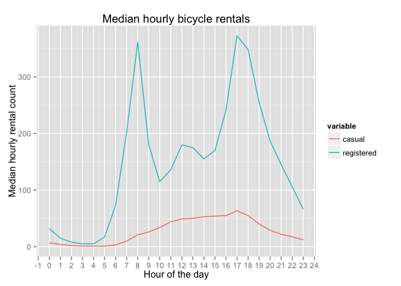

## Description One

In this plot, we see how the registered bicycle rental numbers trump casual bicycle rentals. Looking at these trends gave us an early indication that looking at the number of registered rentals per hour/day would give us a good idea of what the total bicycle rental numbers would look like.

## Plot Two

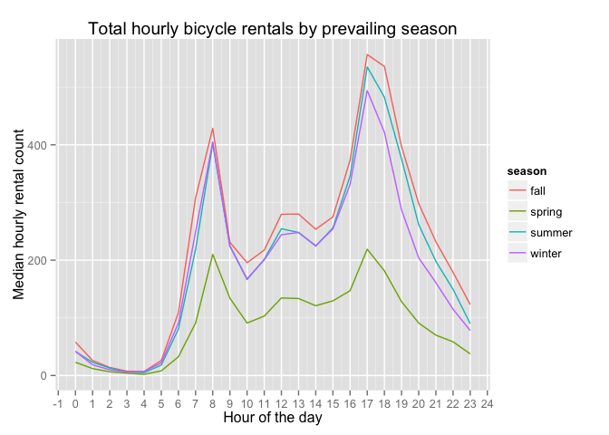

## Description Two

In the previous plot, we see the hourly trends for bicycle rentals across all the observations in the dataset, colored by seasons. In all seasons, we see that one of the hours peaks occurs at 8:00 AM and the second one at 5:00 PM. These peaks suggest that bicycle rentals are utilized by users who use the bikes to get to work/school(since these activities tend to be between fixed times everyday). We see that the cicycle rental numbers fall on either side of the peak, marking their lowest points during the night hours. The general trend holds in all seasons, but the numbers are highest in the fall, followed by summer, winter and spring. I think this is mainly because of temperature, precipitation and other factors associated with the seasons.

## Plot Three

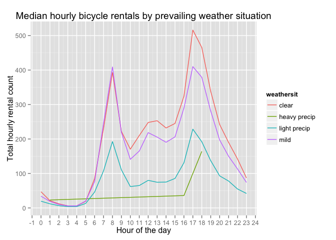

## Description Three

In the previous plot, we see hourly trends for bicycle rentals across all observations in the dataset, colored by the prevailing weather situation. The trends we see in the previous plot are, to some extent, seen in this plot too. Let’s consider the three weather situations - clear, mild and light precipitation first. We see the conventional “commuter peaks” at 8:00 AM and 5:00PM, with ridership falling off on either sides of the peaks. Interestingly, renter behavior is very different during periods of heavy precipitation. Total rentals during heavy precipitation stays close to none in the early hours of the day, peaking slightly at around 6:00 PM.

# Reflection